# Projet_AS

### Total

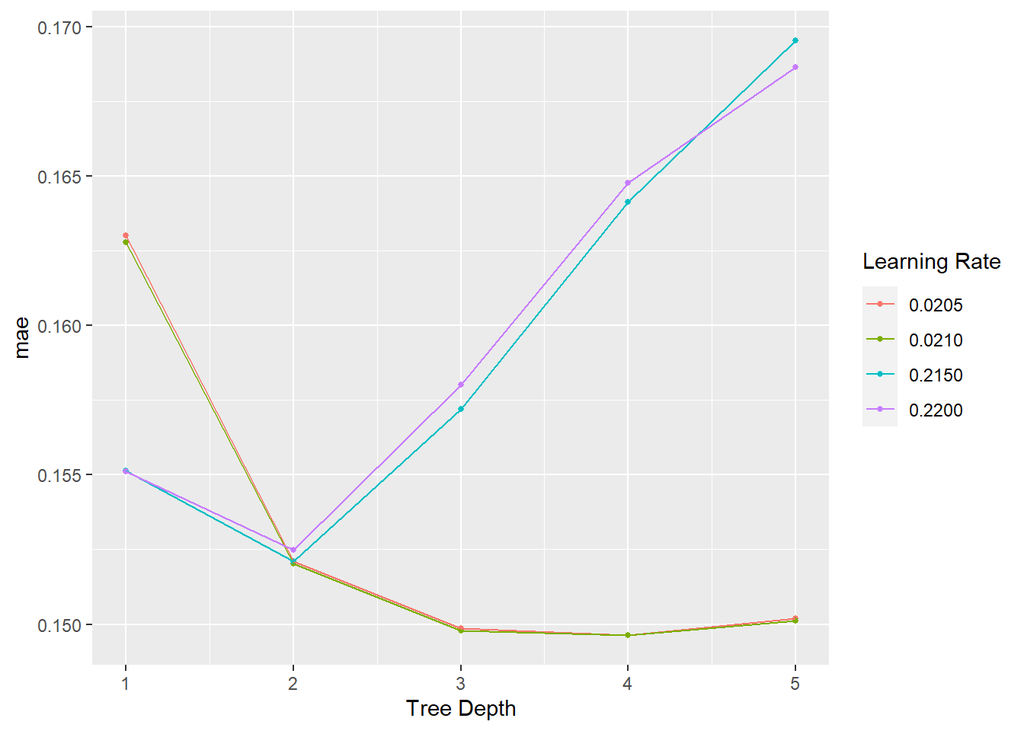

```r
all_data_xg <- subset(all_data, select = -c(nom, Poste, Club, Annee, Poste_global))
all_data_xg <- na.omit(all_data_xg, cols = "Note")

#Diviser en entrainement et test
set.seed(123)
data_split <- initial_split(all_data_xg, prop = 0.65, strata = Note)
data_train <- training(data_split)
data_test <- testing(data_split)

#Préparation des données
variable_a_tester_xg <- c("Age","minJ","Apparences","But","PasseDecisive","Tirs","Dribbles","Passes_perc","moy_passes","centre_perc","interception","tacle","tirsBloques","driblesSubis","fautes","TaclesRecu")
recipe_xg <- recipe(Note ~ ., data = data_train) |>
  update_role(all_of(variable_a_tester_xg), new_role = "predictor") |>
  step_normalize(all_predictors())

xgb_model <-
  boost_tree(
    trees = 1000,
    stop_iter=20,
    min_n = 1,
    tree_depth = tune(),
    learn_rate = tune()
  ) |>
  set_mode("regression") |>
  set_engine("xgboost")

xgb_wf <- workflow() |>
  add_recipe(recipe_xg) |>
  add_model(xgb_model)

play_samples_cv <- vfold_cv(data_train,v=3,repeats=1,strata="Note")

xgb_grid <- expand.grid(tree_depth=c(1,2,3,4,5),learn_rate=c(0.0205,0.0210, 0.215,0.220))

xgb_3fold <- xgb_wf |>
  tune_grid(resamples=play_samples_cv,grid=xgb_grid,
            metrics=metric_set(mae))

xgb_3fold |> autoplot()
```

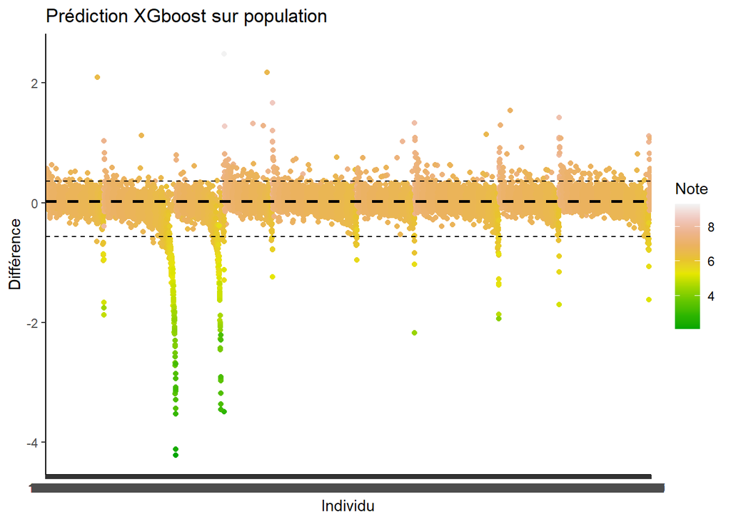

```r
best_par <- xgb_3fold |>
  select_best()

final_xgb <- xgb_wf |>
  finalize_workflow(best_par) |>
  fit(data = data_train)

pred <- final_xgb |>
  predict(new_data=data_test)


data_test_fin <- data_test |> select(Note)
data_test_fin_2 <- cbind(pred, data_test_fin)

data_test_fin_2$Difference <- data_test_fin_2$Note - data_test_fin_2$.pred
data_test_fin_2$DifferenceAbs <- abs(data_test_fin_2$Note - data_test_fin_2$.pred)



# Calculer la médiane et les intervalles de confiance
median_diff <- median(data_test_fin_2$Difference)
ci_low <- quantile(data_test_fin_2$Difference, 0.025)
ci_high <- quantile(data_test_fin_2$Difference, 0.975)

# Créer le plot ggplot2 avec médiane et intervalles de confiance
gg_plot <- ggplot(data_test_fin_2, aes(x = rownames(data_test_fin_2), y = Difference, color = Note)) +
  geom_point() +
  geom_hline(yintercept = median_diff, linetype = "dashed", color = "black", size = 1) +
  geom_hline(yintercept = ci_low, linetype = "dashed", color = "black", size = 0.5)+
  geom_hline(yintercept = ci_high, linetype = "dashed", color = "black", size = 0.5)+
  labs(title = "Prédiction XGboost sur population",
       x = "Individu",
       y = "Différence") +
  scale_colour_gradientn(colours = terrain.colors(10)) +
  theme_classic()

gg_plot
```

```r
R2_tot_xg <- 1 - sum((data_test_fin_2$Note - data_test_fin_2$.pred)^2) / sum((data_test_fin_2$Note - mean(data_test_fin_2$Note))^2)
RMSE_tot_xg <- sqrt(mean((data_test_fin_2$Note - data_test_fin_2$.pred)^2))
erreur_moy_abs_tot_xg <- mean(data_test_fin_2$DifferenceAbs)
```

Nous avons tester pour chaque postes et pour la population totale XGboost on va venir faire un tableau recap prenant :

- Le R2 par model
- Le RMSE
- La différence absolu moyenne = Moyenne ( | Note - note.pred| )

### b) Random Forest

#### Total

```r
library(ranger)
library(caret)
```

```r
library(tidymodels)
library(ggplot2)

# Définir la graine pour la reproductibilité
set.seed(123)

# Séparation des données en ensemble d'entraînement et ensemble de test
data_split <- initial_split(all_data, prop = 0.8, strata = Note)
data_train <- training(data_split)
data_test <- testing(data_split)

# Supprimer les colonnes non pertinentes
data_train <- subset(data_train, select = -c(nom, Poste, Club, Annee, Poste_global))
data_train <- na.omit(data_train, cols = "Note")

data_test <- subset(data_test, select = -c(nom, Poste, Club, Annee, Poste_global))
data_test <- na.omit(data_test, cols = "Note")

# Recherche du meilleur mtry par validation croisée
pargrid_regression <- expand.grid(mtry = 1:16,
                                  splitrule = "variance",
                                  min.node.size = 1)

# Définir le schéma de validation croisée
ctrl <- trainControl(method = "cv", number = 5)

# Entraîner le modèle avec validation croisée
rf_model <- train(Note ~ .,
                  data = data_train,
                  method = "ranger",
                  trControl = ctrl,
                  tuneGrid = pargrid_regression)

# Afficher les résultats de la validation croisée
print(rf_model)
```

```
## Random Forest
##
## 30893 samples
##    16 predictor
##
## No pre-processing
## Resampling: Cross-Validated (5 fold)
## Summary of sample sizes: 24713, 24714, 24716, 24714, 24715
## Resampling results across tuning parameters:
##
##   mtry  RMSE       Rsquared   MAE
##    1    0.2898311  0.3639588  0.1591514
##    2    0.2812521  0.3872400  0.1542763
##    3    0.2800405  0.3893315  0.1542354
##    4    0.2803632  0.3869277  0.1547424
##    5    0.2805950  0.3857341  0.1551736
##    6    0.2814707  0.3820567  0.1556716
##    7    0.2818369  0.3806745  0.1562016
##    8    0.2828080  0.3769252  0.1568625
##    9    0.2831305  0.3758347  0.1571625
##   10    0.2840594  0.3723600  0.1578052
##   11    0.2846480  0.3703208  0.1582382
##   12    0.2852635  0.3681882  0.1586375
##   13    0.2857505  0.3664686  0.1589823
##   14    0.2862665  0.3647728  0.1593214
##   15    0.2867487  0.3629821  0.1597621
##   16    0.2873331  0.3610972  0.1601367
##
## Tuning parameter 'splitrule' was held constant at a value of variance
##
## Tuning parameter 'min.node.size' was held constant at a value of 1
## RMSE was used to select the optimal model using the smallest value.
## The final values used for the model were mtry = 3, splitrule = variance
##  and min.node.size = 1.
```

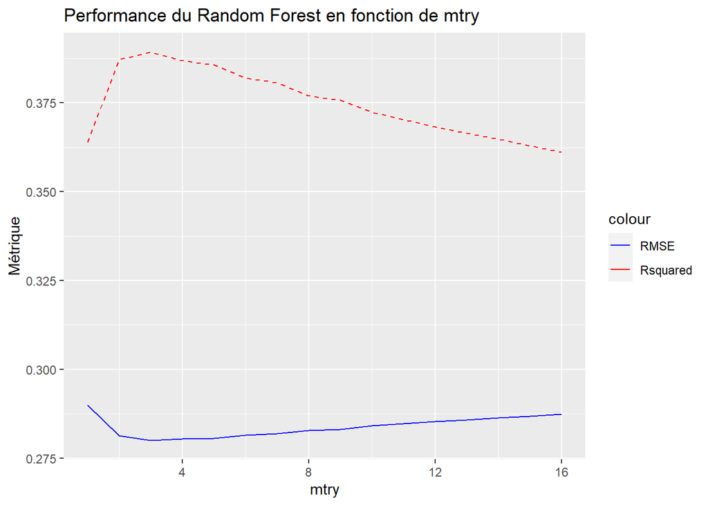

```r
# Tracer la performance en fonction de mtry
ggplot(rf_model$results) +
  geom_line(aes(x = mtry, y = RMSE, color = "RMSE"), linetype = "solid") +
  geom_line(aes(x = mtry, y = Rsquared, color = "Rsquared"), linetype = "dashed") +
  labs(title = "Performance du Random Forest en fonction de mtry",
       x = "mtry",
       y = "Métrique") +
  scale_color_manual(values = c("blue", "red"),
                     labels = c("RMSE", "Rsquared"))
```

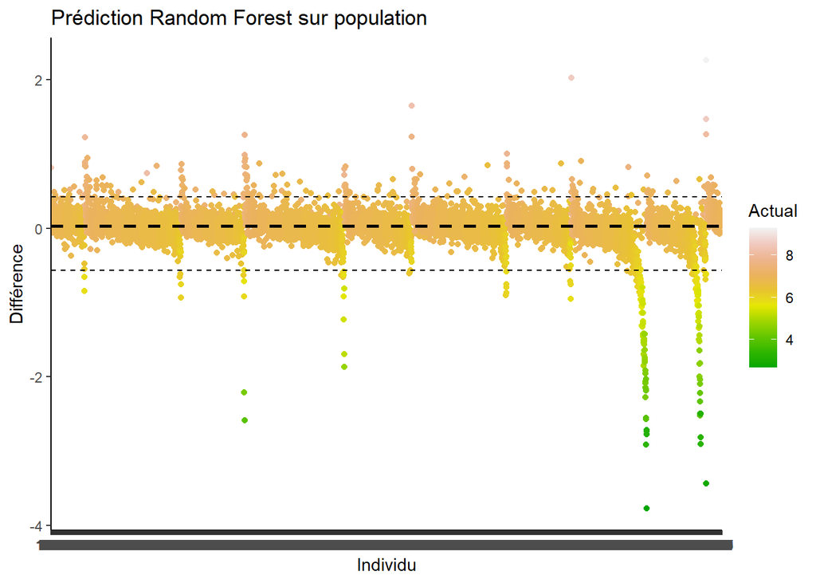

```r
# Sélectionner le modèle optimal
best_mtry <- rf_model$bestTune$mtry

# Entraîner le modèle final avec le meilleur mtry
final_rf_model <- ranger(Note ~ .,
                         data = data_train,
                         mtry = best_mtry)

# Prédiction sur l'ensemble de test
predictions <- predict(final_rf_model, data = data_test)$predictions


# Calculer d'autres métriques d'évaluation
RMSE_tot_rf <- sqrt(mean((data_test$Note - predictions)^2))
R2_tot_rf <- 1 - sum((data_test$Note - predictions)^2) / sum((data_test$Note - mean(data_test$Note))^2)
erreur_moy_abs_tot_rf <- mean(abs(data_test$Note - predictions))

# Créer le dataframe de comparaison
comparison_rf <- data.frame(
  Actual = data_test$Note,
  Predicted = predictions,
  Residuals = data_test$Note - predictions,
  DifferenceAbs = abs(data_test$Note - predictions)

)



# Calculer la médiane et les intervalles de confiance
median_diff <- median(comparison_rf$Residuals)
ci_low <- quantile(comparison_rf$Residuals, 0.025)
ci_high <- quantile(comparison_rf$Residuals, 0.975)

# Créer le plot ggplot2 avec médiane et intervalles de confiance
ggplot(comparison_rf, aes(x = rownames(comparison_rf), y = Residuals, color = Actual)) +
  geom_point() +
  geom_hline(yintercept = median_diff, linetype = "dashed", color = "black", size = 1) +
  geom_hline(yintercept = ci_low, linetype = "dashed", color = "black", size = 0.5) +
  geom_hline(yintercept = ci_high, linetype = "dashed", color = "black", size = 0.5) +   labs(title = "Prédiction Random Forest sur population",
       x = "Individu",
       y = "Différence") +
  scale_colour_gradientn(colours = terrain.colors(10)) +
  theme_classic()
```

### c) Régression linéaire

#### Total

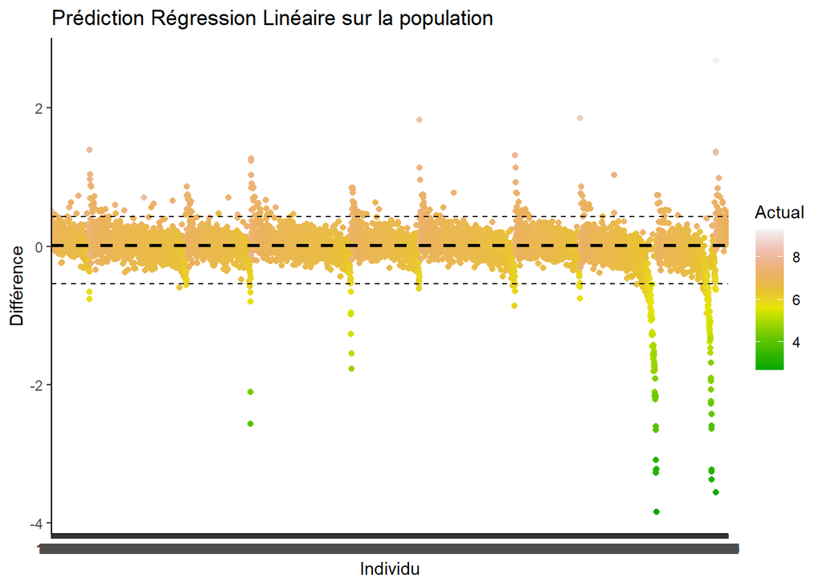

```r
#Division en jeu d'entraienement

# Division en jeu d'entraînement
set.seed(123)
data_split <- initial_split(all_data, prop = 0.8, strata = Note)
data_train <- training(data_split)
data_test <- testing(data_split)

# Préparation des données
data_train <- subset(data_train, select = -c(nom, Poste, Club, Annee, Poste_global))
data_train <- na.omit(data_train, cols = "Note")

data_test <- subset(data_test, select = -c(nom, Poste, Club, Annee, Poste_global))
data_test <- na.omit(data_test, cols = "Note")

# Entraînement du modèle de régression linéaire
lm_fit <- lm(Note ~ ., data = data_train)

# Prédictions sur l'ensemble de test
predictions_lin <- predict(lm_fit, newdata = data_test)
actual_values <- data_test$Note

# Création du dataframe de comparaison
comparison_lin <- data.frame(
  Actual = actual_values,
  Predicted = predictions_lin,
  Residuals = actual_values - predictions_lin
)

# Calcul des statistiques d'évaluation
median_diff <- median(comparison_lin$Actual - comparison_lin$Predicted)
ci_low <- quantile(comparison_lin$Actual - comparison_lin$Predicted, 0.025)
ci_high <- quantile(comparison_lin$Actual - comparison_lin$Predicted, 0.975)

# Création du plot ggplot2
ggplot(comparison_lin, aes(x = rownames(comparison_lin), y = Residuals, color = Actual)) +
  geom_point() +
  geom_hline(yintercept = median_diff, linetype = "dashed", color = "black", size = 1) +
  geom_hline(yintercept = ci_low, linetype = "dashed", color = "black", size = 0.5)+
  geom_hline(yintercept = ci_high, linetype = "dashed", color = "black", size = 0.5)+
  labs(title = "Prédiction Régression Linéaire sur la population",
       x = "Individu",
       y = "Différence") +
  scale_colour_gradientn(colours = terrain.colors(10)) +
  theme_classic()
```

```r
# Calcul des métriques d'évaluation
RMSE_reg_tot <- sqrt(mean(comparison_lin$Residuals^2))
R2_reg_tot <- 1 - sum((comparison_lin$Actual - comparison_lin$Predicted)^2) / sum((comparison_lin$Actual - mean(comparison_lin$Predicted))^2)
erreur_moy_abs_tot_reg <- mean(abs(comparison_lin$Actual - comparison_lin$Predicted))
```

#### Attaquant

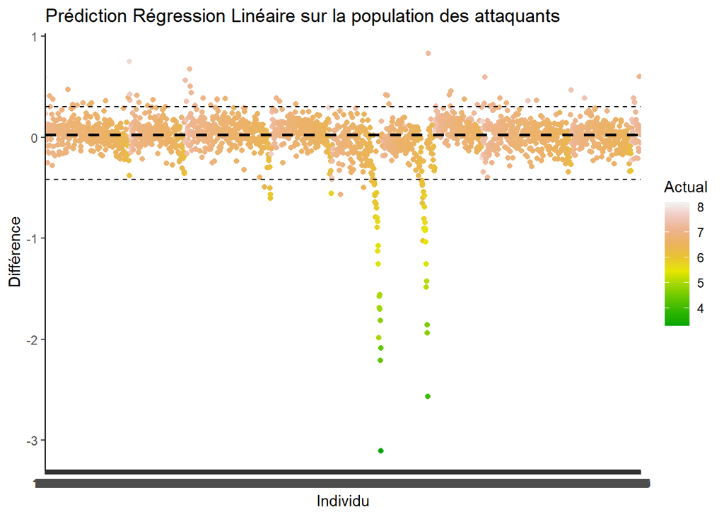

```r
# Division en jeu d'entraînement
set.seed(123)
data_split <- initial_split(all_data, prop = 0.8, strata = Note)
data_train <- training(data_split)
data_test <- testing(data_split)

# Filtrage pour les attaquants
all_data_poste_train <- data_train |> filter(Poste_global == "Attaquant")
all_data_poste_train <- subset(all_data_poste_train, select = -c(nom, Poste, Club, Annee, Poste_global))
all_data_poste_train <- na.omit(all_data_poste_train, cols = "Note")

all_data_poste_test <- data_test |> filter(Poste_global == "Attaquant")
all_data_poste_test <- subset(all_data_poste_test, select = -c(nom, Poste, Club, Annee, Poste_global))
all_data_poste_test <- na.omit(all_data_poste_test, cols = "Note")

# Entraînement du modèle de régression linéaire
lm_fit_att <- lm(Note ~ ., data = all_data_poste_train)

# Prédictions sur l'ensemble de test
predictions_poste_lin_att <- predict(lm_fit_att, newdata = all_data_poste_test)
actual_values <- all_data_poste_test$Note

# Création du dataframe de comparaison
comparison_poste_lin_att <- data.frame(
  Actual = actual_values,
  Predicted = predictions_poste_lin_att,
  Residuals = actual_values - predictions_poste_lin_att
)

# Calcul des statistiques d'évaluation
median_diff <- median(comparison_poste_lin_att$Actual - comparison_poste_lin_att$Predicted)
ci_low <- quantile(comparison_poste_lin_att$Actual - comparison_poste_lin_att$Predicted, 0.025)
ci_high <- quantile(comparison_poste_lin_att$Actual - comparison_poste_lin_att$Predicted, 0.975)

# Création du plot ggplot2
ggplot(comparison_poste_lin_att, aes(x = rownames(comparison_poste_lin_att), y = Residuals, color = Actual)) +
  geom_point() +
  geom_hline(yintercept = median_diff, linetype = "dashed", color = "black", size = 1) +
  geom_hline(yintercept = ci_low, linetype = "dashed", color = "black", size = 0.5)+
  geom_hline(yintercept = ci_high, linetype = "dashed", color = "black", size = 0.5)+
  labs(title = "Prédiction Régression Linéaire sur la population des attaquants",
       x = "Individu",
       y = "Différence") +
  scale_colour_gradientn(colours = terrain.colors(10)) +
  theme_classic()
```

```r
# Calcul des métriques d'évaluation
RMSE_reg_att <- sqrt(mean(comparison_poste_lin_att$Residuals^2))
R2_reg_att <- 1 - sum((comparison_poste_lin_att$Actual - comparison_poste_lin_att$Predicted)^2) / sum((comparison_poste_lin_att$Actual - mean(comparison_poste_lin_att$Predicted))^2)
erreur_moy_abs_att_reg <- mean(abs(comparison_poste_lin_att$Actual - comparison_poste_lin_att$Predicted))
```

### d) Régression Lasso

#### Total

```r
# Définition du modèle LASSO
# Division en jeu d'entraînement
set.seed(123)
data_split <- initial_split(all_data, prop = 0.8, strata = Note)
data_train_2 <- training(data_split)
data_test_2 <- testing(data_split)

# Préparation des données
data_train_3 <- subset(data_train_2, select = -c(nom, Poste, Club, Annee, Poste_global))
data_train <- na.omit(data_train_3, cols = "Note")

data_test_3 <- subset(data_test_2, select = -c(nom, Poste, Club, Annee, Poste_global))
data_test <- na.omit(data_test_3, cols = "Note")

lasso_model <- linear_reg() |>
  set_engine("glmnet") |>
  set_mode("regression") |>
  set_args(penalty = tune(), mixture = 1)

# Création du workflow pour le LASSO
lasso_wf <- workflow() |>
  add_model(lasso_model) |>
  add_formula(Note ~ .)

# Création des folds pour la validation croisée
folds <- vfold_cv(data_train, v = 3, strata = "Note")

# Définition de la grille de recherche du paramètre lambda
lambda_grid <- grid_regular(penalty(range = c(-5, 2)), levels = 100)

# Validation croisée pour le LASSO
lasso_cv <- lasso_wf |>
  tune_grid(resamples = folds, grid = lambda_grid, metrics = metric_set(rsq))
```

```
## → A | warning: A correlation computation is required, but `estimate` is constant and has 0 standard deviation, resulting in a divide by 0 error. `NA` will be returned.
```

```
##
There were issues with some computations   A: x1

There were issues with some computations   A: x2

There were issues with some computations   A: x3

There were issues with some computations   A: x3
```

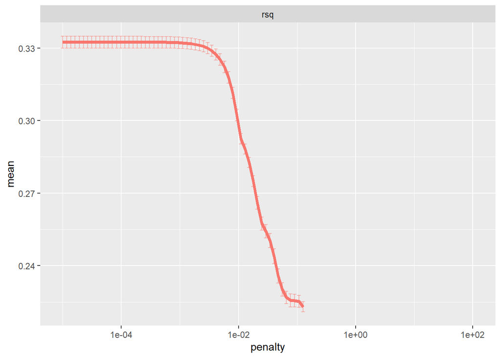

```r
# Collecte des métriques
res <- lasso_cv |> collect_metrics()



lasso_cv |>
  collect_metrics() |>
  ggplot(aes(penalty, mean, color = .metric)) +
  geom_errorbar(aes(
    ymin = mean - std_err,
    ymax = mean + std_err
  ),
  alpha = 0.5
  ) +
  geom_line(size = 1.5) +
  facet_wrap(~.metric, scales = "free", nrow = 2) +
  scale_x_log10() +
  theme(legend.position = "none")
```

```r
# Sélection du meilleur lambda
best_rsq <- lasso_cv |> select_best(metric = "rsq")
best_rsq$penalty
```

```
## [1] 1e-05
```

```r
# Finalisation du workflow avec le meilleur lambda
final_wf <- finalize_workflow(lasso_wf, best_rsq)
print(final_wf)
```

```
## ══ Workflow ════════════════════════════════════════════════════════════════════
## Preprocessor: Formula
## Model: linear_reg()
##
## ── Preprocessor ────────────────────────────────────────────────────────────────
## Note ~ .
##
## ── Model ───────────────────────────────────────────────────────────────────────
## Linear Regression Model Specification (regression)
##
## Main Arguments:
##   penalty = 1e-05
##   mixture = 1
##
## Computational engine: glmnet
```

```r
# Entraînement du modèle LASSO avec le meilleur lambda sur l'ensemble des données d'entraînement
final_lasso <- final_wf |> fit(data_train)

# Tidy sur le modèle LASSO
final_lasso |> tidy()
```

```
## # A tibble: 17 × 3
##    term           estimate penalty
##    <chr>             <dbl>   <dbl>
##  1 (Intercept)    6.57     0.00001
##  2 Age           -0.000530 0.00001
##  3 minJ           0.000215 0.00001
##  4 Apparences    -0.0162   0.00001
##  5 But            0.0141   0.00001
##  6 PasseDecisive  0.00709  0.00001
##  7 Tirs           0.0783   0.00001
##  8 Dribbles      -0.0328   0.00001
##  9 Passes_perc    0.00199  0.00001
## 10 moy_passes     0.184    0.00001
## 11 centre_perc    0        0.00001
## 12 interception   0.0328   0.00001
## 13 tacle          0.0921   0.00001
## 14 tirsBloques    0.0675   0.00001
## 15 driblesSubis  -0.153    0.00001
## 16 fautes        -0.0961   0.00001
## 17 TaclesRecu     0.0448   0.00001
```

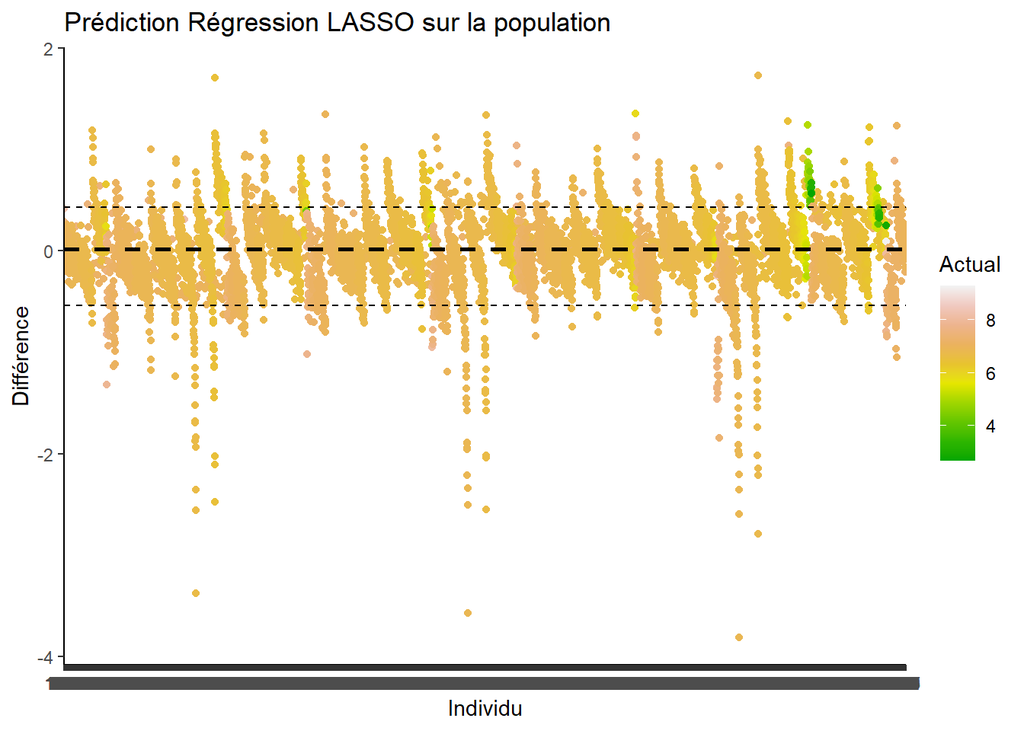

```r
# Prédictions avec le modèle LASSO sur l'ensemble de test
predictions_lasso <- predict(final_lasso, new_data = data_test)
comparison_lasso <- data.frame(Actual = data_test$Note, Predicted = predictions_lasso)
residuals_lasso <- actual_values - predictions_lasso

comparison_lasso <- data.frame(
  Actual = data_test$Note,
  Predicted = predictions_lasso,
  Residuals = residuals_lasso
)
colnames(comparison_lasso) <- c("Actual", "Predicted", "Residuals")

# Calcul des différences et des erreurs absolues
comparison_lasso$Difference <- comparison_lasso$Actual - comparison_lasso$Predicted
comparison_lasso$DifferenceAbs <- abs(comparison_lasso$Actual - comparison_lasso$Predicted)

# Calcul de la médiane et des intervalles de confiance
median_diff <- median(comparison_lasso$Difference)
ci_low <- quantile(comparison_lasso$Difference, 0.025)
ci_high <- quantile(comparison_lasso$Difference, 0.975)

# Création du plot ggplot2
ggplot(comparison_lasso, aes(x = rownames(comparison_lasso), y = Residuals, color = Actual)) +
  geom_point() +
  geom_hline(yintercept = median_diff, linetype = "dashed", color = "black", size = 1) +
  geom_hline(yintercept = ci_low, linetype = "dashed", color = "black", size = 0.5)+
  geom_hline(yintercept = ci_high, linetype = "dashed", color = "black", size = 0.5)+
  labs(title = "Prédiction Régression LASSO sur la population",
       x = "Individu",
       y = "Différence") +
  scale_colour_gradientn(colours = terrain.colors(10)) +
  theme_classic()
```

```r
# Calcul des métriques d'évaluation
RMSE_regLASSO_tot <- sqrt(mean(comparison_lasso$Residuals^2))
R2_regLASSO_tot <- 1 - sum((comparison_lasso$Actual - comparison_lasso$Predicted)^2) / sum((comparison_lasso$Actual - mean(comparison_lasso$Predicted))^2)
erreur_moy_abs_tot_regLASSO <- mean(comparison_lasso$DifferenceAbs)
```

#### Attaquant

```r
set.seed(123)
data_split <- initial_split(all_data, prop = 0.8, strata = Note)
data_train <- training(data_split)
data_test <- testing(data_split)

# Filtrage pour les attaquants
all_data_poste_train <- data_train |> filter(Poste_global == "Attaquant")
all_data_poste_train <- subset(all_data_poste_train, select = -c(nom, Poste, Club, Annee, Poste_global))
all_data_poste_train <- na.omit(all_data_poste_train, cols = "Note")

all_data_poste_test <- data_test |> filter(Poste_global == "Attaquant")
all_data_poste_test <- subset(all_data_poste_test, select = -c(nom, Poste, Club, Annee, Poste_global))
all_data_poste_test <- na.omit(all_data_poste_test, cols = "Note")


lasso_att_model <- linear_reg() |>
  set_engine("glmnet") |>
  set_mode("regression") |>
  set_args(penalty = tune(), mixture = 1)

lasso_att_wf <- workflow() |>
  add_model(lasso_att_model) |>
  add_formula(Note ~ .)

folds <- vfold_cv(all_data_poste_train, v=5, strata = "Note")

lambda_grid <- grid_regular(penalty(range = c(-5, 2)), levels = 100)
lambda_grid$penalty
```

```
##   [1] 1.000000e-05 1.176812e-05 1.384886e-05 1.629751e-05 1.917910e-05
##   [6] 2.257020e-05 2.656088e-05 3.125716e-05 3.678380e-05 4.328761e-05
##  [11] 5.094138e-05 5.994843e-05 7.054802e-05 8.302176e-05 9.770100e-05
##  [16] 1.149757e-04 1.353048e-04 1.592283e-04 1.873817e-04 2.205131e-04
##  [21] 2.595024e-04 3.053856e-04 3.593814e-04 4.229243e-04 4.977024e-04
##  [26] 5.857021e-04 6.892612e-04 8.111308e-04 9.545485e-04 1.123324e-03
##  [31] 1.321941e-03 1.555676e-03 1.830738e-03 2.154435e-03 2.535364e-03
##  [36] 2.983647e-03 3.511192e-03 4.132012e-03 4.862602e-03 5.722368e-03
##  [41] 6.734151e-03 7.924829e-03 9.326033e-03 1.097499e-02 1.291550e-02
##  [46] 1.519911e-02 1.788650e-02 2.104904e-02 2.477076e-02 2.915053e-02
##  [51] 3.430469e-02 4.037017e-02 4.750810e-02 5.590810e-02 6.579332e-02
##  [56] 7.742637e-02 9.111628e-02 1.072267e-01 1.261857e-01 1.484968e-01
##  [61] 1.747528e-01 2.056512e-01 2.420128e-01 2.848036e-01 3.351603e-01
##  [66] 3.944206e-01 4.641589e-01 5.462277e-01 6.428073e-01 7.564633e-01
##  [71] 8.902151e-01 1.047616e+00 1.232847e+00 1.450829e+00 1.707353e+00
##  [76] 2.009233e+00 2.364489e+00 2.782559e+00 3.274549e+00 3.853529e+00
##  [81] 4.534879e+00 5.336699e+00 6.280291e+00 7.390722e+00 8.697490e+00
##  [86] 1.023531e+01 1.204504e+01 1.417474e+01 1.668101e+01 1.963041e+01
##  [91] 2.310130e+01 2.718588e+01 3.199267e+01 3.764936e+01 4.430621e+01
##  [96] 5.214008e+01 6.135907e+01 7.220809e+01 8.497534e+01 1.000000e+02
```

```r
lasso_att_cv <- lasso_att_wf |>
  tune_grid(resamples = folds, grid = lambda_grid, metrics = metric_set(rsq))
```

```
## → A | warning: A correlation computation is required, but `estimate` is constant and has 0 standard deviation, resulting in a divide by 0 error. `NA` will be returned.
```

```
##
There were issues with some computations   A: x1

There were issues with some computations   A: x2

There were issues with some computations   A: x3

There were issues with some computations   A: x4

There were issues with some computations   A: x5

There were issues with some computations   A: x5
```

```r
res <- lasso_att_cv |>
  collect_metrics()


res$mean
```

```
##   [1] 0.4813992 0.4813992 0.4813992 0.4813992 0.4813992 0.4813992 0.4813992
##   [8] 0.4813992 0.4813992 0.4813992 0.4813992 0.4813992 0.4813992 0.4813992
##  [15] 0.4813992 0.4813992 0.4813992 0.4813992 0.4813992 0.4813992 0.4813992
##  [22] 0.4813992 0.4813997 0.4813735 0.4813497 0.4813138 0.4812656 0.4811917
##  [29] 0.4811141 0.4810125 0.4808627 0.4806598 0.4803844 0.4800082 0.4794950
##  [36] 0.4788856 0.4781218 0.4770626 0.4756292 0.4738504 0.4716967 0.4688205
##  [43] 0.4651215 0.4602613 0.4544962 0.4513691 0.4496098 0.4488263 0.4477623
##  [50] 0.4462043 0.4441430 0.4423652 0.4413772 0.4408349 0.4399883 0.4384955
##  [57] 0.4356712 0.4297337 0.4170844 0.3976582 0.3443552 0.3526982       NaN
##  [64]       NaN       NaN       NaN       NaN       NaN       NaN       NaN
##  [71]       NaN       NaN       NaN       NaN       NaN       NaN       NaN
##  [78]       NaN       NaN       NaN       NaN       NaN       NaN       NaN
##  [85]       NaN       NaN       NaN       NaN       NaN       NaN       NaN
##  [92]       NaN       NaN       NaN       NaN       NaN       NaN       NaN
##  [99]       NaN       NaN
```

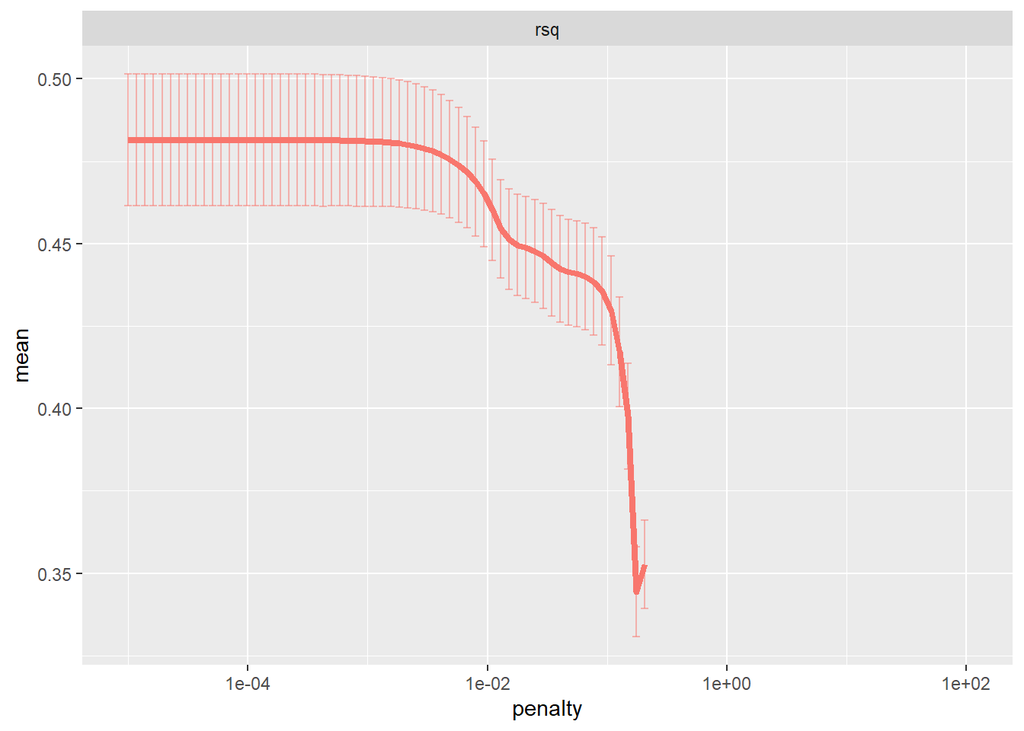

```r
lasso_att_cv |>
  collect_metrics() |>
  ggplot(aes(penalty, mean, color = .metric)) +
  geom_errorbar(aes(
    ymin = mean - std_err,
    ymax = mean + std_err
  ),
  alpha = 0.5
  ) +
  geom_line(size = 1.5) +
  facet_wrap(~.metric, scales = "free", nrow = 2) +
  scale_x_log10() +
  theme(legend.position = "none")
```

```r
# On sélectionne le lambda qui minimise le risque estimé par VC

best_rsq <- lasso_att_cv |>
  select_best(metric="rsq")
best_rsq$penalty
```

```
## [1] 0.0003593814
```

```r
# On relance (entraine) la régression lasso_att avec ce "meilleur" lambda sur l'ensemble du jeu de données pour obtenir le "meilleur" prédicteur lasso_att

final_wf <- finalize_workflow(lasso_att_wf,best_rsq)
print(final_wf)
```

```
## ══ Workflow ════════════════════════════════════════════════════════════════════
## Preprocessor: Formula
## Model: linear_reg()
##
## ── Preprocessor ────────────────────────────────────────────────────────────────
## Note ~ .
##
## ── Model ───────────────────────────────────────────────────────────────────────
## Linear Regression Model Specification (regression)
##
## Main Arguments:
##   penalty = 0.000359381366380463
##   mixture = 1
##
## Computational engine: glmnet
```

```r
final_lasso_att <- final_wf |>
  fit(all_data_poste_train)

final_lasso_att |> tidy()
```

```
## # A tibble: 17 × 3
##    term            estimate  penalty
##    <chr>              <dbl>    <dbl>
##  1 (Intercept)    6.43      0.000359
##  2 Age           -0.00104   0.000359
##  3 minJ          -0.0000546 0.000359
##  4 Apparences    -0.00318   0.000359
##  5 But            0.0224    0.000359
##  6 PasseDecisive  0.0144    0.000359
##  7 Tirs           0.102     0.000359
##  8 Dribbles      -0.00911   0.000359
##  9 Passes_perc    0.00131   0.000359
## 10 moy_passes     0.236     0.000359
## 11 centre_perc    0.000444  0.000359
## 12 interception   0.0710    0.000359
## 13 tacle          0.0990    0.000359
## 14 tirsBloques    0.175     0.000359
## 15 driblesSubis  -0.116     0.000359
## 16 fautes        -0.0320    0.000359
## 17 TaclesRecu     0.0565    0.000359
```

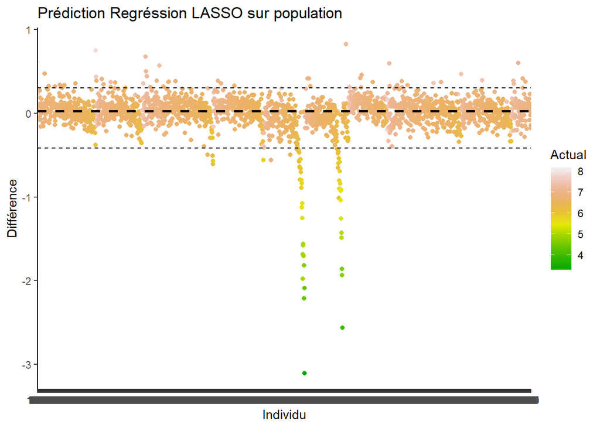

```r
predictions_poste_lasso_att <- predict(final_lasso_att, new_data = all_data_poste_test)
comparison_poste_lasso_att <- data.frame(Actual = all_data_poste_test$Note, Predicted = predictions_poste_lasso_att)
residuals_lasso_att <- actual_values - predictions_poste_lasso_att

comparison_poste_lasso_att <- data.frame(
  Actual = actual_values,
  Predicted = predictions_poste_lasso_att,
  Residuals = residuals_lasso_att
)
colnames(comparison_poste_lasso_att) <- c("Actual", "Predicted", "Residuals")

comparison_poste_lasso_att$Difference <- comparison_poste_lasso_att$Actual - comparison_poste_lasso_att$Predicted
comparison_poste_lasso_att$DifferenceAbs <- abs(comparison_poste_lasso_att$Actual - comparison_poste_lasso_att$Predicted)




# Calculer la médiane et les intervalles de confiance
median_diff <- median(comparison_poste_lasso_att$Difference)
ci_low <- quantile(comparison_poste_lasso_att$Difference, 0.025)
ci_high <- quantile(comparison_poste_lasso_att$Difference, 0.975)

# Créer le plot ggplot2 avec médiane et intervalles de confiance
ggplot(comparison_poste_lasso_att, aes(x = rownames(comparison_poste_lasso_att), y = Difference, color = Actual)) +
  geom_point() +
  geom_hline(yintercept = median_diff, linetype = "dashed", color = "black", size = 1) +
  geom_hline(yintercept = ci_low, linetype = "dashed", color = "black", size = 0.5)+
  geom_hline(yintercept = ci_high, linetype = "dashed", color = "black", size = 0.5)+
  labs(title = "Prédiction Regréssion LASSO sur population",
       x = "Individu",
       y = "Différence") +
  scale_colour_gradientn(colours = terrain.colors(10)) +
  theme_classic()
```

```r
RMSE_regLASSO_att <- sqrt(mean(comparison_poste_lasso_att$Residuals^2))
R2_regLASSO_att <- 1 - sum((comparison_poste_lasso_att$Actual - comparison_poste_lasso_att$Predicted)^2) / sum((comparison_poste_lasso_att$Actual - mean(comparison_poste_lasso_att$Predicted))^2)
erreur_moy_abs_att_regLASSO <- mean(comparison_poste_lasso_att$DifferenceAbs)
```

### e) Régression Ridge

#### Total

```r
# Régression RIDGE avec validation croisée
set.seed(123)
data_split <- initial_split(all_data, prop = 0.8, strata = Note)
data_train_2 <- training(data_split)
data_test_2 <- testing(data_split)

# Préparation des données
data_train_3 <- subset(data_train_2, select = -c(nom, Poste, Club, Annee, Poste_global))
data_train <- na.omit(data_train_3, cols = "Note")

data_test_3 <- subset(data_test_2, select = -c(nom, Poste, Club, Annee, Poste_global))
data_test <- na.omit(data_test_3, cols = "Note")

ridge_model <- linear_reg() |>
  set_engine("glmnet") |>
  set_mode("regression") |>
  set_args(penalty = tune(), mixture = 0)

ridge_wf <- workflow() |>
  add_model(ridge_model) |>
  add_formula(Note ~ .)


ridge_cv <- ridge_wf |>
  tune_grid(resamples = folds, grid = lambda_grid, metrics = metric_set(rsq))


res <- ridge_cv |>
  collect_metrics()


res$mean
```

```
##   [1] 0.4801563 0.4801563 0.4801563 0.4801563 0.4801563 0.4801563 0.4801563
##   [8] 0.4801563 0.4801563 0.4801563 0.4801563 0.4801563 0.4801563 0.4801563
##  [15] 0.4801563 0.4801563 0.4801563 0.4801563 0.4801563 0.4801563 0.4801563
##  [22] 0.4801563 0.4801563 0.4801563 0.4801563 0.4801563 0.4801563 0.4801563
##  [29] 0.4801563 0.4801563 0.4801563 0.4801563 0.4801563 0.4801563 0.4801563
##  [36] 0.4801563 0.4801563 0.4801563 0.4801563 0.4801563 0.4801563 0.4801563
##  [43] 0.4801563 0.4801563 0.4801563 0.4801563 0.4801563 0.4801518 0.4797687
##  [50] 0.4792747 0.4786499 0.4778652 0.4768917 0.4756768 0.4741915 0.4724133
##  [57] 0.4703052 0.4678368 0.4649698 0.4616944 0.4580379 0.4540111 0.4496171
##  [64] 0.4449151 0.4400067 0.4349495 0.4297750 0.4245896 0.4195182 0.4146108
##  [71] 0.4098730 0.4053847 0.4012316 0.3974108 0.3938827 0.3906772 0.3878275
##  [78] 0.3852964 0.3830308 0.3810230 0.3792840 0.3777725 0.3764430 0.3752836
##  [85] 0.3742941 0.3734459 0.3727069 0.3720683 0.3715285 0.3710684 0.3706695
##  [92] 0.3703266 0.3700381 0.3697931 0.3695814 0.3693998 0.3692481 0.3691188
##  [99] 0.3690071 0.3689116
```

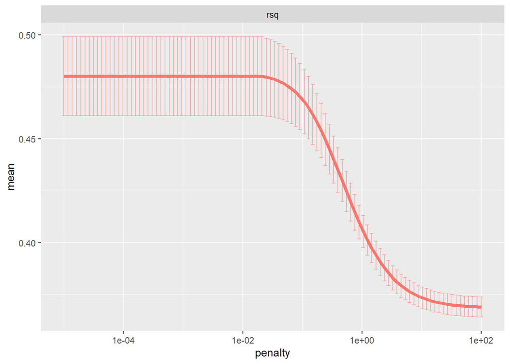

```r
ridge_cv |>
  collect_metrics() |>
  ggplot(aes(penalty, mean, color = .metric)) +
  geom_errorbar(aes(
    ymin = mean - std_err,
    ymax = mean + std_err
  ),
  alpha = 0.5
  ) +
  geom_line(size = 1.5) +
  facet_wrap(~.metric, scales = "free", nrow = 2) +
  scale_x_log10() +
  theme(legend.position = "none")
```

```r
# On sélectionne le lambda qui minimise le risque estimé par VC

best_rsq <- ridge_cv |>
  select_best(metric="rsq")
best_rsq$penalty
```

```
## [1] 1e-05
```

```r
# On relance (entraine) la régression ridge avec ce "meilleur" lambda sur l'ensemble du jeu de données pour obtenir le "meilleur" prédicteur ridge

final_wf <- finalize_workflow(ridge_wf,best_rsq)
print(final_wf)
```

```
## ══ Workflow ════════════════════════════════════════════════════════════════════
## Preprocessor: Formula
## Model: linear_reg()
##
## ── Preprocessor ────────────────────────────────────────────────────────────────
## Note ~ .
##
## ── Model ───────────────────────────────────────────────────────────────────────
## Linear Regression Model Specification (regression)
##
## Main Arguments:
##   penalty = 1e-05
##   mixture = 0
##
## Computational engine: glmnet
```

```r
final_ridge <- final_wf |>
  fit(data_train)

final_ridge |> tidy()
```

```
## # A tibble: 17 × 3
##    term           estimate penalty
##    <chr>             <dbl>   <dbl>
##  1 (Intercept)    6.55     0.00001
##  2 Age           -0.000220 0.00001
##  3 minJ           0.000142 0.00001
##  4 Apparences    -0.00944  0.00001
##  5 But            0.0132   0.00001
##  6 PasseDecisive  0.00771  0.00001
##  7 Tirs           0.0750   0.00001
##  8 Dribbles      -0.0293   0.00001
##  9 Passes_perc    0.00160  0.00001
## 10 moy_passes     0.179    0.00001
## 11 centre_perc   -0.000123 0.00001
## 12 interception   0.0432   0.00001
## 13 tacle          0.0862   0.00001
## 14 tirsBloques    0.0921   0.00001
## 15 driblesSubis  -0.142    0.00001
## 16 fautes        -0.0922   0.00001
## 17 TaclesRecu     0.0445   0.00001
```

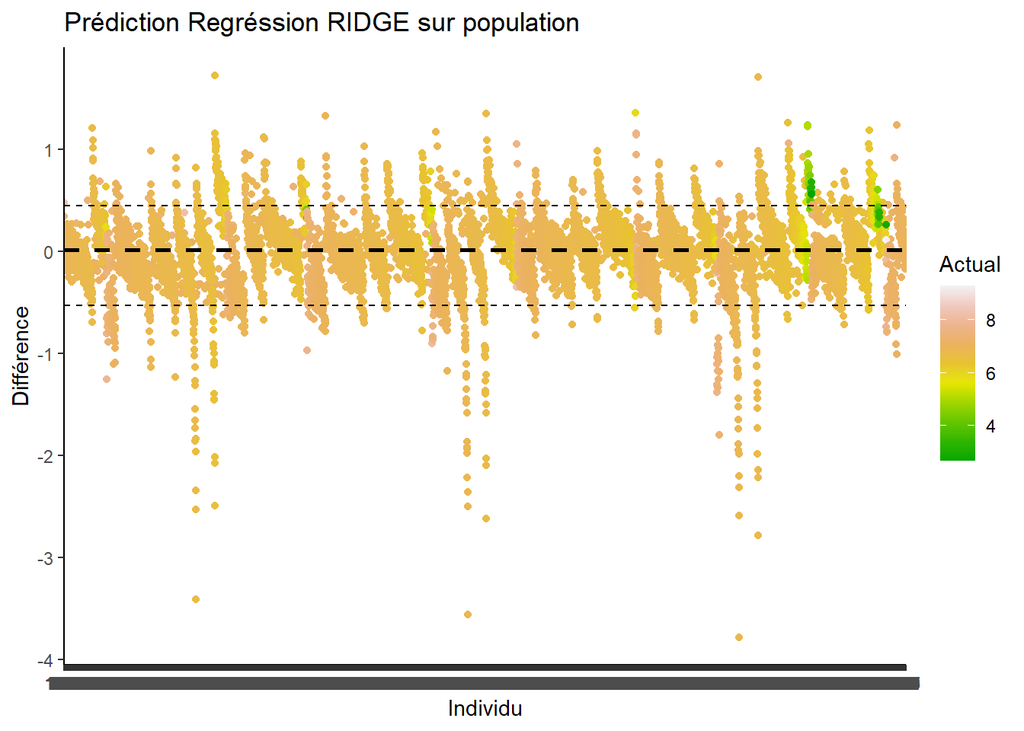

```r
predictions_ridge <- predict(final_ridge, new_data = data_test)
residuals_ridge <- actual_values - predictions_ridge

comparison_ridge <- data.frame(
  Actual = data_test$Note,
  Predicted = predictions_ridge,
  Residuals = residuals_ridge
)
colnames(comparison_ridge) <- c("Actual", "Predicted", "Residuals")

comparison_ridge$Difference <- comparison_ridge$Actual - comparison_ridge$Predicted
comparison_ridge$DifferenceAbs <- abs(comparison_ridge$Actual - comparison_ridge$Predicted)




# Calculer la médiane et les intervalles de confiance
median_diff <- median(comparison_ridge$Difference)
ci_low <- quantile(comparison_ridge$Difference, 0.025)
ci_high <- quantile(comparison_ridge$Difference, 0.975)

# Créer le plot ggplot2 avec médiane et intervalles de confiance
ggplot(comparison_ridge, aes(x = rownames(comparison_ridge), y = Residuals, color = Actual)) +
  geom_point() +
  geom_hline(yintercept = median_diff, linetype = "dashed", color = "black", size = 1) +
  geom_hline(yintercept = ci_low, linetype = "dashed", color = "black", size = 0.5)+
  geom_hline(yintercept = ci_high, linetype = "dashed", color = "black", size = 0.5)+
  labs(title = "Prédiction Regréssion RIDGE sur population",
       x = "Individu",
       y = "Différence") +
  scale_colour_gradientn(colours = terrain.colors(10)) +
  theme_classic()
```

```r
RMSE_regRIDGE_tot <- sqrt(mean(comparison_ridge$Residuals^2))
R2_regRIDGE_tot <- 1 - sum((comparison_ridge$Actual - comparison_ridge$Predicted)^2) / sum((comparison_ridge$Actual - mean(comparison_ridge$Predicted))^2)
erreur_moy_abs_tot_regRIDGE <- mean(comparison_ridge$DifferenceAbs)
```

#### Attaquant

```r
set.seed(123)
data_split <- initial_split(all_data, prop = 0.8, strata = Note)
data_train <- training(data_split)
data_test <- testing(data_split)

# Filtrage pour les attaquants
all_data_poste_train <- data_train |> filter(Poste_global == "Attaquant")
all_data_poste_train <- subset(all_data_poste_train, select = -c(nom, Poste, Club, Annee, Poste_global))
all_data_poste_train <- na.omit(all_data_poste_train, cols = "Note")

all_data_poste_test <- data_test |> filter(Poste_global == "Attaquant")
all_data_poste_test <- subset(all_data_poste_test, select = -c(nom, Poste, Club, Annee, Poste_global))
all_data_poste_test <- na.omit(all_data_poste_test, cols = "Note")

ridge_att_model <- linear_reg() |>
  set_engine("glmnet") |>
  set_mode("regression") |>
  set_args(penalty = tune(), mixture = 0)

ridge_att_wf <- workflow() |>
  add_model(ridge_att_model) |>
  add_formula(Note ~ .)


ridge_att_cv <- ridge_att_wf |>
  tune_grid(resamples = folds, grid = lambda_grid, metrics = metric_set(rsq))


res <- ridge_att_cv |>
  collect_metrics()


res$mean
```

```
##   [1] 0.4801563 0.4801563 0.4801563 0.4801563 0.4801563 0.4801563 0.4801563
##   [8] 0.4801563 0.4801563 0.4801563 0.4801563 0.4801563 0.4801563 0.4801563
##  [15] 0.4801563 0.4801563 0.4801563 0.4801563 0.4801563 0.4801563 0.4801563
##  [22] 0.4801563 0.4801563 0.4801563 0.4801563 0.4801563 0.4801563 0.4801563
##  [29] 0.4801563 0.4801563 0.4801563 0.4801563 0.4801563 0.4801563 0.4801563
##  [36] 0.4801563 0.4801563 0.4801563 0.4801563 0.4801563 0.4801563 0.4801563
##  [43] 0.4801563 0.4801563 0.4801563 0.4801563 0.4801563 0.4801518 0.4797687
##  [50] 0.4792747 0.4786499 0.4778652 0.4768917 0.4756768 0.4741915 0.4724133
##  [57] 0.4703052 0.4678368 0.4649698 0.4616944 0.4580379 0.4540111 0.4496171
##  [64] 0.4449151 0.4400067 0.4349495 0.4297750 0.4245896 0.4195182 0.4146108
##  [71] 0.4098730 0.4053847 0.4012316 0.3974108 0.3938827 0.3906772 0.3878275
##  [78] 0.3852964 0.3830308 0.3810230 0.3792840 0.3777725 0.3764430 0.3752836
##  [85] 0.3742941 0.3734459 0.3727069 0.3720683 0.3715285 0.3710684 0.3706695
##  [92] 0.3703266 0.3700381 0.3697931 0.3695814 0.3693998 0.3692481 0.3691188
##  [99] 0.3690071 0.3689116
```

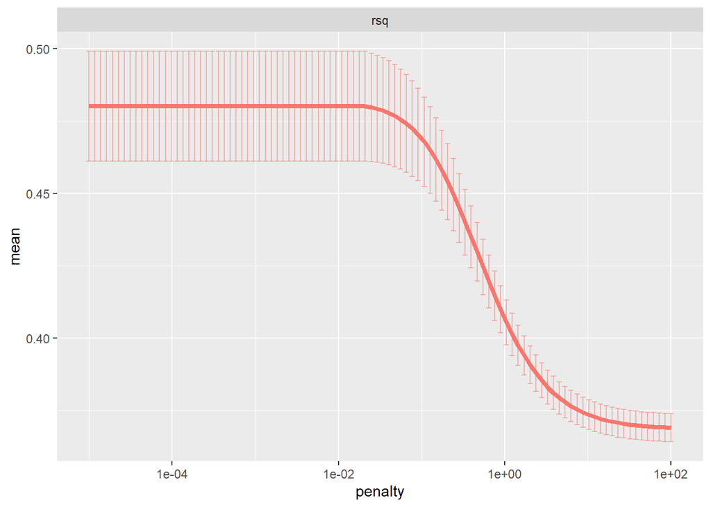

```r
ridge_att_cv |>
  collect_metrics() |>
  ggplot(aes(penalty, mean, color = .metric)) +
  geom_errorbar(aes(
    ymin = mean - std_err,
    ymax = mean + std_err
  ),
  alpha = 0.5
  ) +
  geom_line(size = 1.5) +
  facet_wrap(~.metric, scales = "free", nrow = 2) +
  scale_x_log10() +
  theme(legend.position = "none")
```

```r
# On sélectionne le lambda qui minimise le risque estimé par VC

best_rsq <- ridge_att_cv |>
  select_best(metric="rsq")
best_rsq$penalty
```

```
## [1] 1e-05
```

```r
# On relance (entraine) la régression ridge_att avec ce "meilleur" lambda sur l'ensemble du jeu de données pour obtenir le "meilleur" prédicteur ridge_att

final_wf <- finalize_workflow(ridge_att_wf,best_rsq)
print(final_wf)
```

```
## ══ Workflow ════════════════════════════════════════════════════════════════════
## Preprocessor: Formula
## Model: linear_reg()
##
## ── Preprocessor ────────────────────────────────────────────────────────────────
## Note ~ .
##
## ── Model ───────────────────────────────────────────────────────────────────────
## Linear Regression Model Specification (regression)
##
## Main Arguments:
##   penalty = 1e-05
##   mixture = 0
##
## Computational engine: glmnet
```

```r
final_ridge_att <- final_wf |>
  fit(all_data_poste_train)

final_ridge_att |> tidy()
```

```
## # A tibble: 17 × 3
##    term            estimate penalty
##    <chr>              <dbl>   <dbl>
##  1 (Intercept)    6.44      0.00001
##  2 Age           -0.000897  0.00001
##  3 minJ          -0.0000317 0.00001
##  4 Apparences    -0.00342   0.00001
##  5 But            0.0191    0.00001
##  6 PasseDecisive  0.0152    0.00001
##  7 Tirs           0.103     0.00001
##  8 Dribbles      -0.00537   0.00001
##  9 Passes_perc    0.00123   0.00001
## 10 moy_passes     0.214     0.00001
## 11 centre_perc    0.000540  0.00001
## 12 interception   0.0646    0.00001
## 13 tacle          0.0884    0.00001
## 14 tirsBloques    0.171     0.00001
## 15 driblesSubis  -0.105     0.00001
## 16 fautes        -0.0297    0.00001
## 17 TaclesRecu     0.0530    0.00001
```

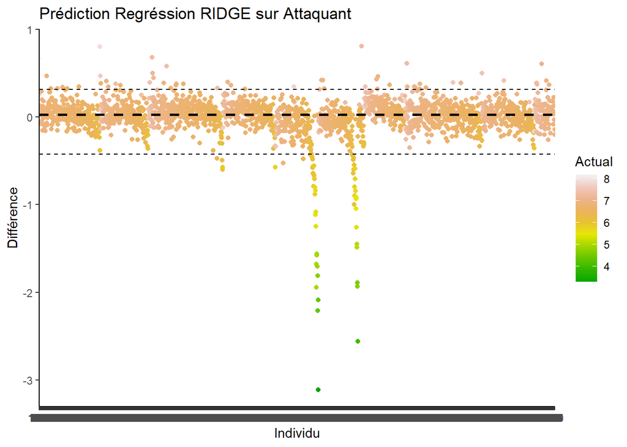

```r
predictions_poste_ridge_att <- predict(final_ridge_att, new_data = all_data_poste_test)
comparison_poste_ridge_att <- data.frame(Actual = actual_values, Predicted = predictions_poste_ridge_att)
residuals_ridge_att <- actual_values - predictions_poste_ridge_att

comparison_poste_ridge_att <- data.frame(
  Actual = actual_values,
  Predicted = predictions_poste_ridge_att,
  Residuals = residuals_ridge_att
)
colnames(comparison_poste_ridge_att) <- c("Actual", "Predicted", "Residuals")

comparison_poste_ridge_att$Difference <- comparison_poste_ridge_att$Actual - comparison_poste_ridge_att$Predicted
comparison_poste_ridge_att$DifferenceAbs <- abs(comparison_poste_ridge_att$Actual - comparison_poste_ridge_att$Predicted)




# Calculer la médiane et les intervalles de confiance
median_diff <- median(comparison_poste_ridge_att$Difference)
ci_low <- quantile(comparison_poste_ridge_att$Difference, 0.025)
ci_high <- quantile(comparison_poste_ridge_att$Difference, 0.975)

# Créer le plot ggplot2 avec médiane et intervalles de confiance
ggplot(comparison_poste_ridge_att, aes(x = rownames(comparison_poste_ridge_att), y = Difference, color = Actual)) +
  geom_point() +
  geom_hline(yintercept = median_diff, linetype = "dashed", color = "black", size = 1) +
  geom_hline(yintercept = ci_low, linetype = "dashed", color = "black", size = 0.5)+
  geom_hline(yintercept = ci_high, linetype = "dashed", color = "black", size = 0.5)+
  labs(title = "Prédiction Regréssion RIDGE sur Attaquant",
       x = "Individu",
       y = "Différence") +
  scale_colour_gradientn(colours = terrain.colors(10)) +
  theme_classic()
```

```r
RMSE_regRIDGE_att <- sqrt(mean(comparison_poste_ridge_att$Residuals^2))
R2_regRIDGE_att <- 1 - sum((comparison_poste_ridge_att$Actual - comparison_poste_ridge_att$Predicted)^2) / sum((comparison_poste_ridge_att$Actual - mean(comparison_poste_ridge_att$Predicted))^2)
erreur_moy_abs_att_regRIDGE <- mean(comparison_poste_ridge_att$DifferenceAbs)
```

### g) Recap

```r
recap <- data.frame(
  Model = c("XG_att", "XG_mil", "XG_def", "XG_gar", "XG_tot", "Reg_tot","Reg_att", "Reg_LASSO","Reg_LASSO_att", "Reg_RIDGE", "Reg_RIDGE_att", "Rf_tot"),
  R2 = c(R2_att_xg, R2_mil_xg, R2_def_xg, R2_gar_xg, R2_tot_xg, R2_reg_tot,R2_reg_att, R2_regLASSO_tot,R2_regLASSO_att, R2_regRIDGE_tot, R2_regRIDGE_att, R2_tot_rf),
  RMSE = c(RMSE_att_xg, RMSE_mil_xg, RMSE_def_xg, RMSE_gar_xg, RMSE_tot_xg, RMSE_reg_tot,RMSE_reg_att, RMSE_regLASSO_tot,RMSE_regLASSO_att, RMSE_regRIDGE_tot, RMSE_regRIDGE_att, RMSE_tot_rf),
  DifMoyAbs = c(erreur_moy_abs_att_xg, erreur_moy_abs_mil_xg, erreur_moy_abs_def_xg, erreur_moy_abs_gar_xg, erreur_moy_abs_tot_xg, erreur_moy_abs_tot_reg,erreur_moy_abs_att_reg,erreur_moy_abs_att_regLASSO, erreur_moy_abs_tot_regLASSO, erreur_moy_abs_tot_regRIDGE, erreur_moy_abs_att_regRIDGE,erreur_moy_abs_tot_rf)
)

recap <- recap %>%
  mutate_at(vars(RMSE, R2, DifMoyAbs), ~ round(., 4))

print(recap)
```

```
##            Model     R2   RMSE DifMoyAbs
## 1         XG_att 0.4680 0.2650    0.1386
## 2         XG_mil 0.4536 0.2600    0.1431
## 3         XG_def 0.3587 0.2543    0.1449
## 4         XG_gar 0.0549 0.3741    0.2524
## 5         XG_tot 0.3894 0.2837    0.1517
## 6        Reg_tot 0.3304 0.2922    0.1643
## 7        Reg_att 0.5126 0.2311    0.1285
## 8      Reg_LASSO 0.3304 0.3788    0.1284
## 9  Reg_LASSO_att 0.5130 0.2310    0.1641
## 10     Reg_RIDGE 0.3256 0.3734    0.1622
## 11 Reg_RIDGE_att 0.5118 0.2312    0.1283
## 12        Rf_tot 0.3882 0.2793    0.1541
```

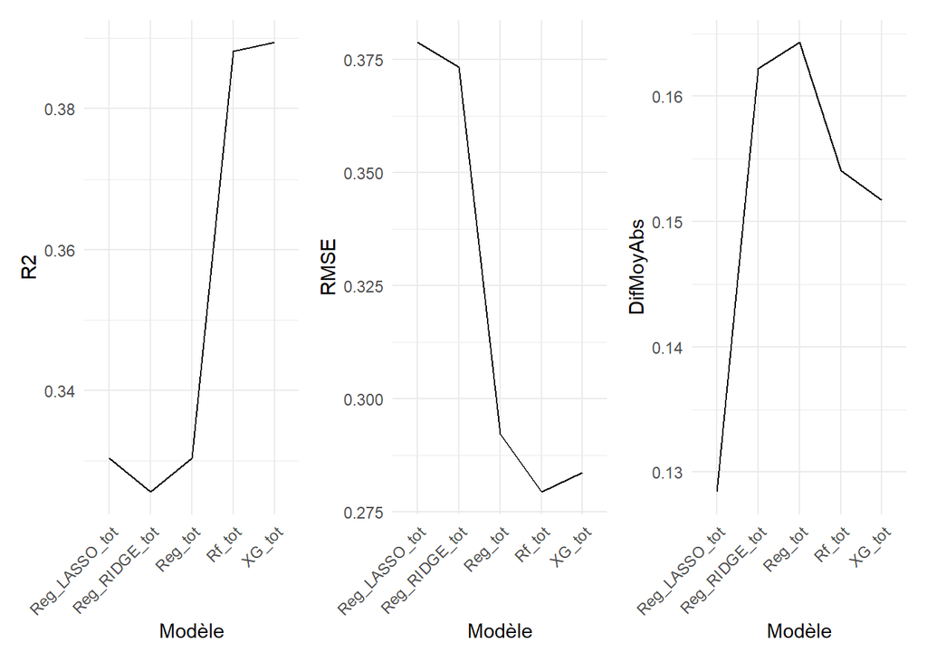

```r
## Afin d'éviter de relancer tout les modèles nous placons ici un récap des différent smodèles
recap <- data.frame(
  Model = c("XG_att", "XG_mil", "XG_def", "XG_gar", "XG_tot",
            "Reg_tot", "Reg_att", "Reg_LASSO_tot", "Reg_LASSO_att",
            "Reg_RIDGE_tot", "Reg_RIDGE_att", "Rf_tot"),
  R2 = c(0.4680, 0.4536, 0.3587, 0.0549, 0.3894, 0.3304,
         0.5126, 0.3304, 0.5130, 0.3256, 0.5118, 0.3882),
  RMSE = c(0.2650, 0.2600, 0.2543, 0.3741, 0.2837, 0.2922,
           0.2311, 0.3788, 0.2310, 0.3734, 0.2312, 0.2793),
  DifMoyAbs = c(0.1386, 0.1431, 0.1449, 0.2524, 0.1517, 0.1643,
                0.1285, 0.1284, 0.1641, 0.1622, 0.1283, 0.1541)
)

library(ggplot2)
library(patchwork)
# Filtrer les modèles contenant "tot" dans leur nom
recap_tot <- recap[grep("tot", recap$Model), ]

# Créer trois graphiques linéaires pour chaque variable
# R2
plot_r2 <- ggplot(recap_tot, aes(x = Model, y = R2, group = 1)) +
  geom_line() +
  labs(
       x = "Modèle",
       y = "R2") +
  theme_minimal() +
  theme(axis.text.x = element_text(angle = 45, hjust = 1))

# RMSE
plot_rmse <- ggplot(recap_tot, aes(x = Model, y = RMSE, group = 1)) +
  geom_line() +
  labs(
       x = "Modèle",
       y = "RMSE") +
  theme_minimal() +
  theme(axis.text.x = element_text(angle = 45, hjust = 1))

# DifMoyAbs
plot_dif <- ggplot(recap_tot, aes(x = Model, y = DifMoyAbs, group = 1)) +
  geom_line() +
  labs(
       x = "Modèle",
       y = "DifMoyAbs") +
  theme_minimal() +
  theme(axis.text.x = element_text(angle = 45, hjust = 1))

# Combinaison des trois graphiques
combined_plot <- plot_r2 + plot_rmse + plot_dif

# Affichage de la combinaison
combined_plot
```

## Conclusion de sélection de modèle

Pour conclure sur la sélection de modèle, dans notre cas va s’opérer sur la population totale ( c’est à dire l’ensemble des postes de chacun des joeueurs). On veut un modèle qui soit le plus puissant possible pour prédire la note de joeueurs évoluant sur différents postes.

Toutefois nous avons identifier quelques axes d’améliorations que l’on pourrait inclure à notre modèle pour le rendre légérement plus restrictif mais plus puissant :

- Transformer les variables pour qu’elles représentente toutes la même unités de mesures ( Dans notre jeu de données la quasi-totalités des variables sont exprimés par % sur un match ou par moyenne par matchs à l’exception de trois ( Min Joués, But et passes décisives nous allons donc essyayer de transformer cela afin d’étudier les gains de précisions de ce dernier).

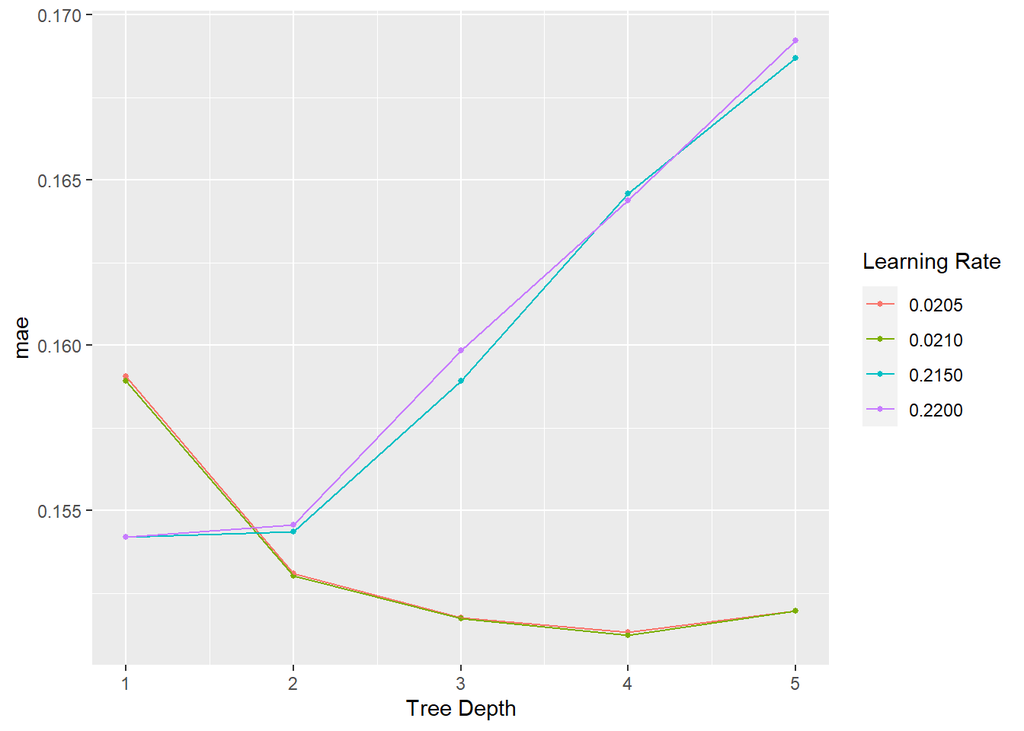

```r
#Modification des variables dans le but de les uniformiser
test_data <- all_data |> mutate(MJ_match = minJ/Apparences,
                                But_match = (But/minJ)*90,
                                PasseDe_match = (PasseDecisive/minJ)*90)


all_data_xg <- subset(test_data, select = -c(nom, Poste, Club, Annee, Poste_global, minJ, But, PasseDecisive))
all_data_xg <- na.omit(all_data_xg, cols = "Note")

#Diviser en entrainement et test
set.seed(123)
data_split <- initial_split(all_data_xg, prop = 0.65, strata = Note)
data_train <- training(data_split)
data_test <- testing(data_split)

#Préparation des données
variable_a_tester_xg <- c("Age","MJ_match","But_match","PasseDe_match","Tirs","Dribbles","Passes_perc","moy_passes","centre_perc","interception","tacle","tirsBloques","driblesSubis","fautes","TaclesRecu")

recipe_xg <- recipe(Note ~ ., data = data_train) |>
  update_role(all_of(variable_a_tester_xg), new_role = "predictor") |>
  step_normalize(all_numeric_predictors())

xgb_model <-
  boost_tree(
    trees = 1000,
    stop_iter=20,
    min_n = 1,
    tree_depth = tune(),
    learn_rate = tune()
  ) |>
  set_mode("regression") |>
  set_engine("xgboost")

xgb_wf <- workflow() |>
  add_recipe(recipe_xg) |>
  add_model(xgb_model)

play_samples_cv <- vfold_cv(data_train,v=3,repeats=1,strata="Note")

xgb_grid <- expand.grid(tree_depth=c(1,2,3,4,5),learn_rate=c(0.0205,0.0210, 0.215,0.220))

xgb_3fold <- xgb_wf |>
  tune_grid(resamples=play_samples_cv,grid=xgb_grid,
            metrics=metric_set(mae))

xgb_3fold |> autoplot()
```

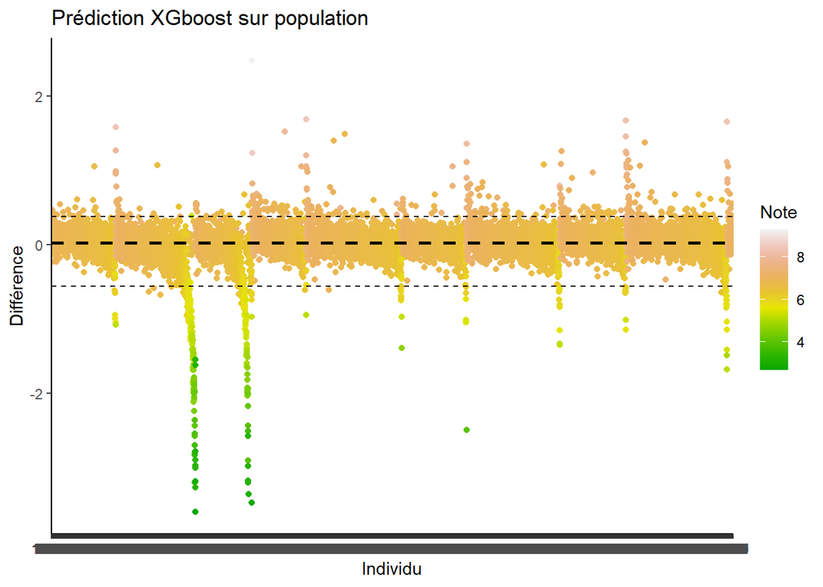

```r
best_par <- xgb_3fold |>
  select_best()

final_xgb <- xgb_wf |>
  finalize_workflow(best_par) |>
  fit(data = data_train)

pred <- final_xgb |>
  predict(new_data=data_test)


data_test_fin <- data_test |> select(Note)
data_test_fin_2 <- cbind(pred, data_test_fin)

data_test_fin_2$Difference <- data_test_fin_2$Note - data_test_fin_2$.pred
data_test_fin_2$DifferenceAbs <- abs(data_test_fin_2$Note - data_test_fin_2$.pred)



# Calculer la médiane et les intervalles de confiance
median_diff <- median(data_test_fin_2$Difference)
ci_low <- quantile(data_test_fin_2$Difference, 0.025)
ci_high <- quantile(data_test_fin_2$Difference, 0.975)

# Créer le plot ggplot2 avec médiane et intervalles de confiance
gg_plot <- ggplot(data_test_fin_2, aes(x = rownames(data_test_fin_2), y = Difference, color = Note)) +
  geom_point() +
  geom_hline(yintercept = median_diff, linetype = "dashed", color = "black", size = 1) +
  geom_hline(yintercept = ci_low, linetype = "dashed", color = "black", size = 0.5)+
  geom_hline(yintercept = ci_high, linetype = "dashed", color = "black", size = 0.5)+
  labs(title = "Prédiction XGboost sur population",
       x = "Individu",
       y = "Différence") +
  scale_colour_gradientn(colours = terrain.colors(10)) +
  theme_classic()

gg_plot
```

```r
R2_tot_xg_trans1 <- 1 - sum((data_test_fin_2$Note - data_test_fin_2$.pred)^2) / sum((data_test_fin_2$Note - mean(data_test_fin_2$Note))^2)
RMSE_tot_xg_trans1 <- sqrt(mean((data_test_fin_2$Note - data_test_fin_2$.pred)^2))
erreur_moy_abs_tot_xg_trans1 <- mean(data_test_fin_2$DifferenceAbs)
```

- Si on se fixe également sur un point de vue sportif. Evaluer des joueurs qui joue très peu dans un match ou sur l’ensemble de la saison ne nous semble pas cohérent (nous décidons donc de laisser uniquement les joueurs jouant plus de 270 min sur la saison et plus de 45 min par apparitions)

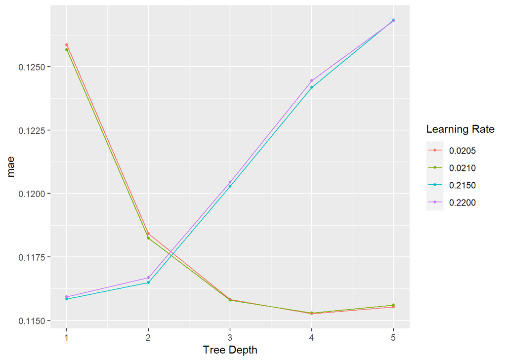

```r
#Supprimer les joueurs qui joue peu
test_data <- all_data |> mutate(MJ_match = minJ/Apparences,
                                But_match = (But/minJ)*90,
                                PasseDe_match = (PasseDecisive/minJ)*90)
all_data_2 <- test_data |> filter(minJ >270)
all_data_2 <- all_data_2 |> filter(MJ_match > 45)

all_data_xg <- subset(all_data_2, select = -c(nom, Poste, Club, Annee, Poste_global, minJ, But, PasseDecisive))
all_data_xg <- na.omit(all_data_xg, cols = "Note")

#Diviser en entrainement et test
set.seed(123)
data_split <- initial_split(all_data_xg, prop = 0.65, strata = Note)
data_train <- training(data_split)
data_test <- testing(data_split)

#Préparation des données
variable_a_tester_xg <- c("Age","MJ_match","But_match","PasseDe_match","Tirs","Dribbles","Passes_perc","moy_passes","centre_perc","interception","tacle","tirsBloques","driblesSubis","fautes","TaclesRecu")

recipe_xg <- recipe(Note ~ ., data = data_train) |>
  update_role(all_of(variable_a_tester_xg), new_role = "predictor") |>
  step_normalize(all_numeric_predictors())

xgb_model <-
  boost_tree(
    trees = 1000,
    stop_iter=20,
    min_n = 1,
    tree_depth = tune(),
    learn_rate = tune()
  ) |>
  set_mode("regression") |>
  set_engine("xgboost")

xgb_wf <- workflow() |>
  add_recipe(recipe_xg) |>
  add_model(xgb_model)

play_samples_cv <- vfold_cv(data_train,v=3,repeats=1,strata="Note")

xgb_grid <- expand.grid(tree_depth=c(1,2,3,4,5),learn_rate=c(0.0205,0.0210, 0.215,0.220))

xgb_3fold <- xgb_wf |>
  tune_grid(resamples=play_samples_cv,grid=xgb_grid,
            metrics=metric_set(mae))

xgb_3fold |> autoplot()
```

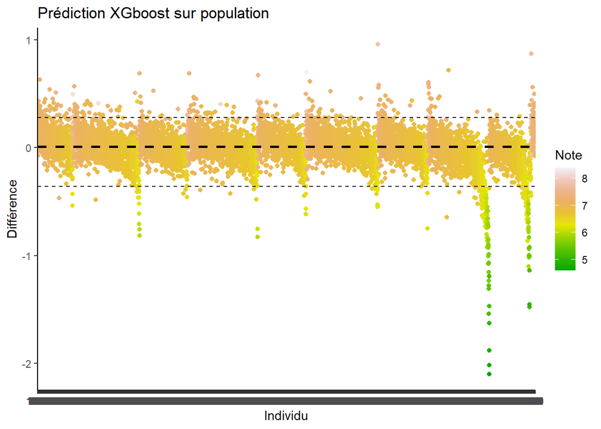

```r
best_par <- xgb_3fold |>
  select_best()

final_xgb <- xgb_wf |>
  finalize_workflow(best_par) |>
  fit(data = data_train)

pred <- final_xgb |>
  predict(new_data=data_test)


data_test_fin <- data_test |> select(Note)
data_test_fin_2 <- cbind(pred, data_test_fin)

data_test_fin_2$Difference <- data_test_fin_2$Note - data_test_fin_2$.pred
data_test_fin_2$DifferenceAbs <- abs(data_test_fin_2$Note - data_test_fin_2$.pred)



# Calculer la médiane et les intervalles de confiance
median_diff <- median(data_test_fin_2$Difference)
ci_low <- quantile(data_test_fin_2$Difference, 0.025)
ci_high <- quantile(data_test_fin_2$Difference, 0.975)

# Créer le plot ggplot2 avec médiane et intervalles de confiance
gg_plot <- ggplot(data_test_fin_2, aes(x = rownames(data_test_fin_2), y = Difference, color = Note)) +
  geom_point() +
  geom_hline(yintercept = median_diff, linetype = "dashed", color = "black", size = 1) +
  geom_hline(yintercept = ci_low, linetype = "dashed", color = "black", size = 0.5)+
  geom_hline(yintercept = ci_high, linetype = "dashed", color = "black", size = 0.5)+
  labs(title = "Prédiction XGboost sur population",
       x = "Individu",
       y = "Différence") +
  scale_colour_gradientn(colours = terrain.colors(10)) +
  theme_classic()

gg_plot
```

```r
R2_tot_xg_trans2 <- 1 - sum((data_test_fin_2$Note - data_test_fin_2$.pred)^2) / sum((data_test_fin_2$Note - mean(data_test_fin_2$Note))^2)
RMSE_tot_xg_trans2 <- sqrt(mean((data_test_fin_2$Note - data_test_fin_2$.pred)^2))
erreur_moy_abs_tot_xg_trans2 <- mean(data_test_fin_2$DifferenceAbs)
```

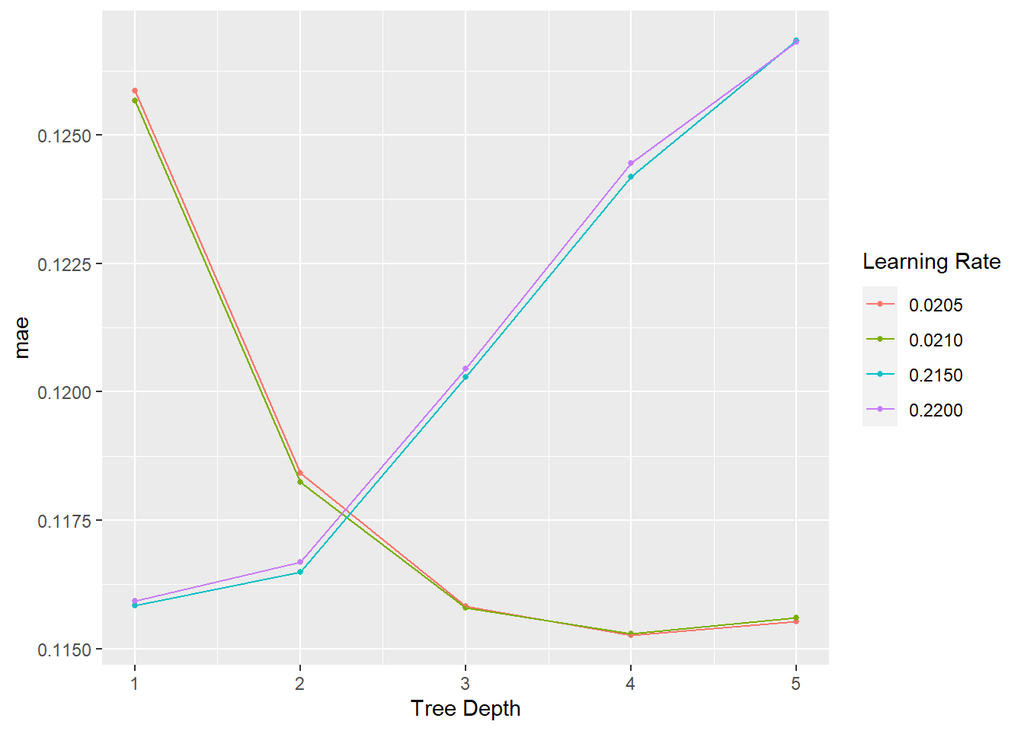

```r
#Ajouter un filtre des notes pour garder une grand epartie de la popuation mais exclure les cas les plus extrêmes
test_data <- all_data |> mutate(MJ_match = minJ/Apparences,
                                But_match = (But/minJ)*90,
                                PasseDe_match = (PasseDecisive/minJ)*90)
all_data_2 <- test_data |> filter(minJ >270)
all_data_2 <- all_data_2 |> filter(MJ_match > 45)
all_data_3 <- all_data_2 |> filter(Note >= 6)
all_data_4 <- all_data_3 |> filter(Note <= 8)


all_data_xg <- subset(all_data_2, select = -c(nom, Poste, Club, Annee, Poste_global, minJ, But, PasseDecisive))
all_data_xg <- na.omit(all_data_xg, cols = "Note")

#Diviser en entrainement et test
set.seed(123)
data_split <- initial_split(all_data_xg, prop = 0.65, strata = Note)
data_train <- training(data_split)
data_test <- testing(data_split)

#Préparation des données
variable_a_tester_xg <- c("Age","MJ_match","But_match","PasseDe_match","Tirs","Dribbles","Passes_perc","moy_passes","centre_perc","interception","tacle","tirsBloques","driblesSubis","fautes","TaclesRecu")

recipe_xg <- recipe(Note ~ ., data = data_train) |>
  update_role(all_of(variable_a_tester_xg), new_role = "predictor") |>
  step_normalize(all_numeric_predictors())

xgb_model <-
  boost_tree(
    trees = 1000,
    stop_iter=20,
    min_n = 1,
    tree_depth = tune(),
    learn_rate = tune()
  ) |>
  set_mode("regression") |>
  set_engine("xgboost")

xgb_wf <- workflow() |>
  add_recipe(recipe_xg) |>
  add_model(xgb_model)

play_samples_cv <- vfold_cv(data_train,v=3,repeats=1,strata="Note")

xgb_grid <- expand.grid(tree_depth=c(1,2,3,4,5),learn_rate=c(0.0205,0.0210, 0.215,0.220))

xgb_3fold <- xgb_wf |>
  tune_grid(resamples=play_samples_cv,grid=xgb_grid,
            metrics=metric_set(mae))

xgb_3fold |> autoplot()
```

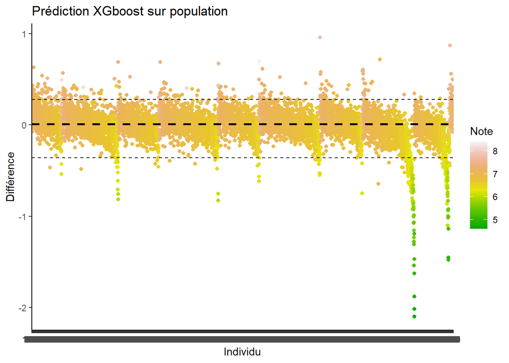

```r
best_par <- xgb_3fold |>
  select_best()

final_xgb <- xgb_wf |>
  finalize_workflow(best_par) |>
  fit(data = data_train)

pred <- final_xgb |>
  predict(new_data=data_test)


data_test_fin <- data_test |> select(Note)
data_test_fin_2 <- cbind(pred, data_test_fin)

data_test_fin_2$Difference <- data_test_fin_2$Note - data_test_fin_2$.pred
data_test_fin_2$DifferenceAbs <- abs(data_test_fin_2$Note - data_test_fin_2$.pred)



# Calculer la médiane et les intervalles de confiance
median_diff <- median(data_test_fin_2$Difference)
ci_low <- quantile(data_test_fin_2$Difference, 0.025)
ci_high <- quantile(data_test_fin_2$Difference, 0.975)

# Créer le plot ggplot2 avec médiane et intervalles de confiance
gg_plot <- ggplot(data_test_fin_2, aes(x = rownames(data_test_fin_2), y = Difference, color = Note)) +
  geom_point() +
  geom_hline(yintercept = median_diff, linetype = "dashed", color = "black", size = 1) +
  geom_hline(yintercept = ci_low, linetype = "dashed", color = "black", size = 0.5)+
  geom_hline(yintercept = ci_high, linetype = "dashed", color = "black", size = 0.5)+
  labs(title = "Prédiction XGboost sur population",
       x = "Individu",
       y = "Différence") +
  scale_colour_gradientn(colours = terrain.colors(10)) +
  theme_classic()

gg_plot
```

```r
R2_tot_xg_trans3 <- 1 - sum((data_test_fin_2$Note - data_test_fin_2$.pred)^2) / sum((data_test_fin_2$Note - mean(data_test_fin_2$Note))^2)
RMSE_tot_xg_trans3 <- sqrt(mean((data_test_fin_2$Note - data_test_fin_2$.pred)^2))
erreur_moy_abs_tot_xg_trans3 <- mean(data_test_fin_2$DifferenceAbs)
```

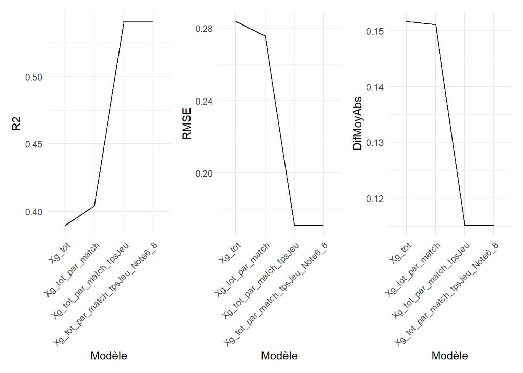

```r
#Amélioration de modèle
df_recap_xg <- data.frame(
  Model = c("Xg_tot", "Xg_tot_par_match", "Xg_tot_par_match_tpsJeu", "Xg_tot_par_match_tpsJeu_Note6_8"),
  R2 = c(R2_tot_xg, R2_tot_xg_trans1, R2_tot_xg_trans2, R2_tot_xg_trans3),
  RMSE = c(RMSE_tot_xg, RMSE_tot_xg_trans1, RMSE_tot_xg_trans2, RMSE_tot_xg_trans3),
  DiffAbsMoy = c(erreur_moy_abs_tot_xg, erreur_moy_abs_tot_xg_trans1, erreur_moy_abs_tot_xg_trans2, erreur_moy_abs_tot_xg_trans3)
)

plot_r2 <- ggplot(df_recap_xg, aes(x = Model, y = R2, group = 1)) +
  geom_line() +
  labs(
       x = "Modèle",
       y = "R2") +
  theme_minimal() +
  theme(axis.text.x = element_text(angle = 45, hjust = 1))

# RMSE
plot_rmse <- ggplot(df_recap_xg, aes(x = Model, y = RMSE, group = 1)) +
  geom_line() +
  labs(
       x = "Modèle",
       y = "RMSE") +
  theme_minimal() +
  theme(axis.text.x = element_text(angle = 45, hjust = 1))

# DifMoyAbs
plot_dif <- ggplot(df_recap_xg, aes(x = Model, y = DiffAbsMoy, group = 1)) +
  geom_line() +
  labs(
       x = "Modèle",
       y = "DifMoyAbs") +
  theme_minimal() +
  theme(axis.text.x = element_text(angle = 45, hjust = 1))

# Combinaison des trois graphiques
combined_plot <- plot_r2 + plot_rmse + plot_dif

# Affichage de la combinaison
combined_plot
```

Pour conclure, le fil du rouge de ce projet à été d’utiliser les différents modèles de Machine learning vue en cours dans le but de répondre à une problématique (dans notre cas un problème de régression). En se basant sur 3 indicateurs de performances des modèles de régression (R2, RMSE et et diffAbsMoy, nous avons essayer d’estimer au mieux les notes de joueurs à partir d’un ensemble de variables). L’ensemble des modèles à été FineTuner par validation croisée pour sélectionner les meilleurs paramètres pour chacun des modèles.